# Model Tests and EDA

1716655

12/11/2019

The below code groups all data as the mean across an album. Use of mean provisional, may make sense to use sum for things like duration, or mins and maxes to see hits. It also removes uninteresting columns, like strings and ids

```r
myData <- {myData %>%
    group_by(ArtistPopularity, ArtistNumFollowers,
             AlbumBestChartPosition, AlbumWeeksOnChart, AlbumWeeksNumberOne,
             AlbumPopularity, Release_year, Release_month, Season, isPop, isFolk,
             isRock, isIndie, isTechno, isRap, isJazz, isMetal, isBlues, isPunk) %>%
    summarize(AlbumLoudness = mean(TrackLoudness),
              AlbumTempo = mean(TrackTempo),
              AlbumAvgDuration = mean(TrackDuration),
              AlbumDanceability = mean(TrackDanceability),
              AlbumEnergy = mean(TrackEnergy),
              AlbumKey = mean(TrackKey),
              AlbumSpeechiness = mean(TrackSpeechiness),
              AlbumAcousticness = mean(TrackAcousticness),
              AlbumInstrumentalness = mean(TrackInstrumentalness),
              AlbumLiveness = mean(TrackLiveness),
              AlbumValence = mean(TrackValence),
              AlbumTimeSignature = mean(TrackTimeSignature),

              AlbumTempo = mean(TrackTempo)
    )}
```

## On artists and the metrics of popularity

There is strong correlation between artist popularity and album popularity, and interestingly weeker correlation between album popularity and weeks on chart. We may need to develop more sophisticated measures of popularity. A look at the API gives us that popularity is established based off of the number of plays, with recent plays higher. This will probably bias towards recent tracks, with older songs having to perform more consistently to secure high popularity. This will be explored in the next block. A look at the graph also seems to indicate a bunching effect - it appears that popularity is probably not linear to listens. However, Artist and Album popularity seem to use the same scale. Plotting the log of the number of followers gives a (stochasitc) linear relationship, indicating an exponential scale is used. This is worth bearing in mind - stakeholders may have a linear interest in listens, depending on how profits are made (a price per play obviously favours a linear relationship between popularity and utility.)

```r
cor(myData$ArtistPopularity, myData$AlbumPopularity)
```

```
## [1] 0.8139244
```

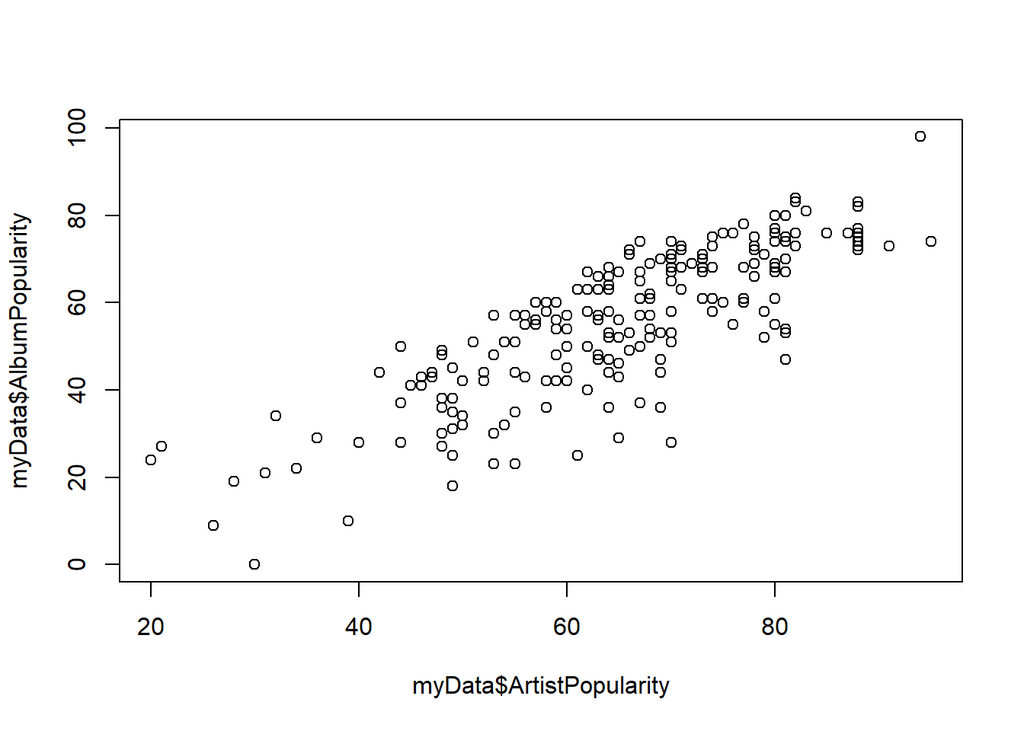

```r
plot(myData$ArtistPopularity, myData$AlbumPopularity)
```

```r
cor(myData$ArtistNumFollowers, myData$AlbumPopularity)
```

```
## [1] 0.5223981
```

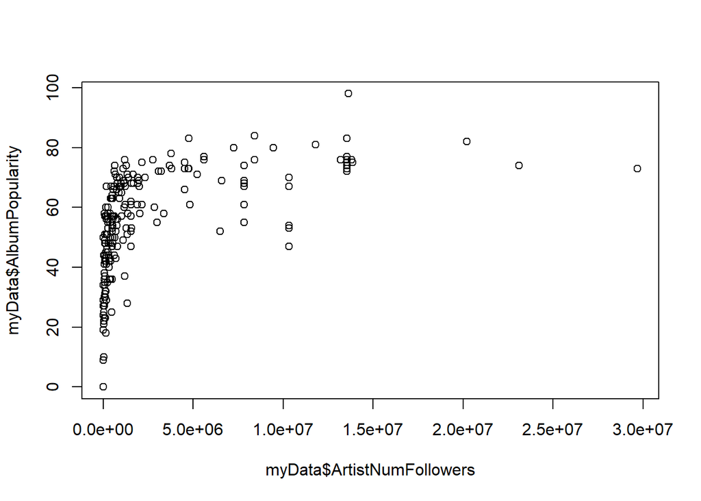

```r
plot(myData$ArtistNumFollowers, myData$AlbumPopularity)
```

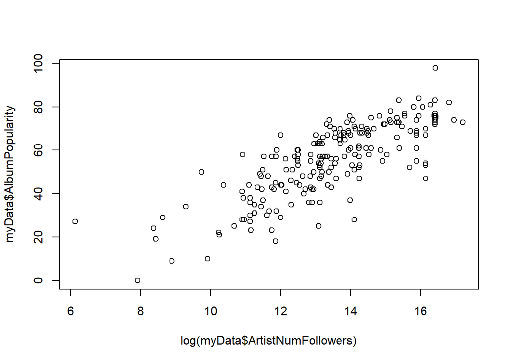

```r
plot(log(myData$ArtistNumFollowers), myData$AlbumPopularity)
```

```r
cor(log(myData$ArtistNumFollowers), myData$AlbumPopularity)
```

```
## [1] 0.7928277
```

```r
cor(myData$ArtistPopularity, myData$AlbumWeeksOnChart)
```

```
## [1] 0.3578504
```

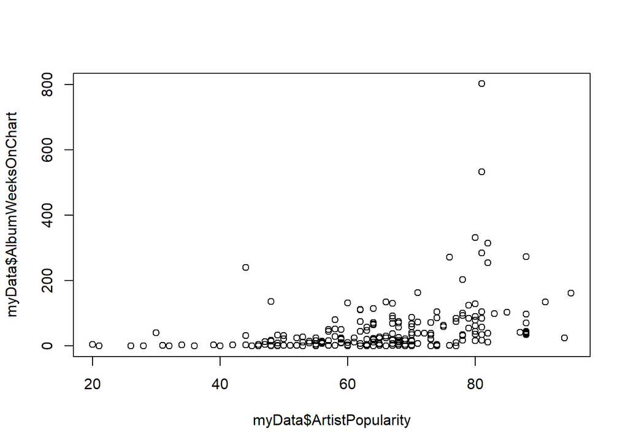

```r
plot(myData$ArtistPopularity, myData$AlbumWeeksOnChart)
```

```r
cor(myData$AlbumWeeksNumberOne, myData$AlbumPopularity)
```

```
## [1] 0.2766834
```

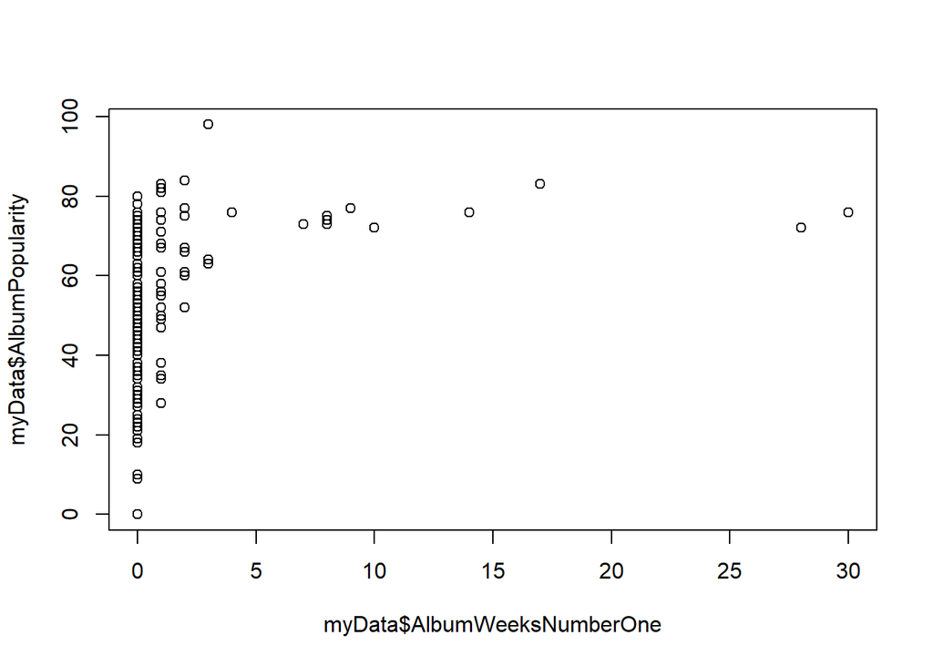

```r
plot(myData$AlbumWeeksNumberOne, myData$AlbumPopularity)
```

```r
cor(myData$AlbumPopularity, myData$AlbumWeeksOnChart)
```

```
## [1] 0.3900119
```

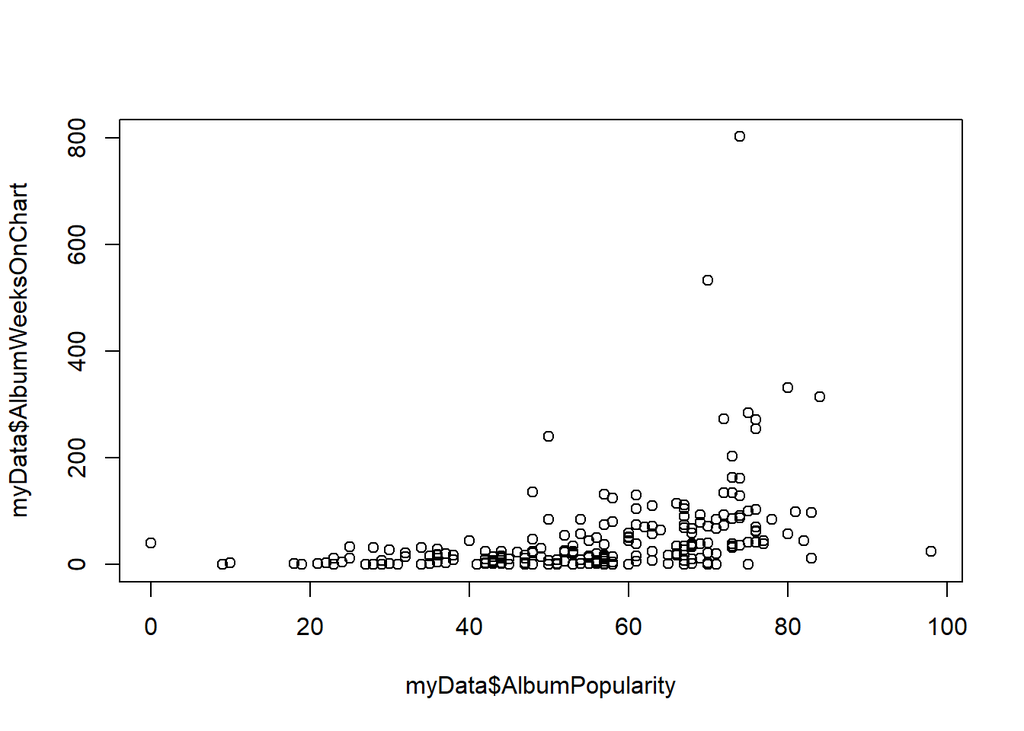

```r
plot(myData$AlbumPopularity, myData$AlbumWeeksOnChart)
```

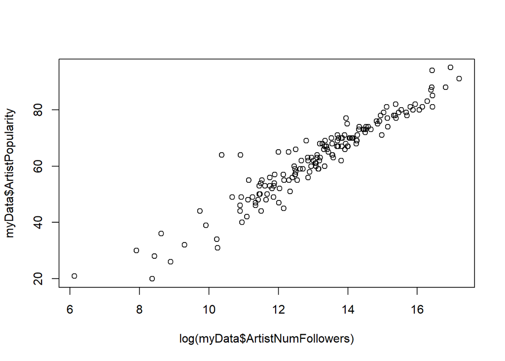

```r
plot(log(myData$ArtistNumFollowers), myData$ArtistPopularity)
```

```r
cor(log(myData$ArtistNumFollowers), myData$ArtistPopularity)
```

```
## [1] 0.9603525
```

## On time

Correlation between release year and popularity exists, however it is low. Perhaps unsurprisingly, recent albums tend to have less weeks on the chart. Controlling for the most recent years eliminates this correlation. This would indicate that whilst old music is listend to less often, it still performed well on release. Whether this shows people moving on from music they have heard before or changing tastes remains to be seen. Further analysis remains to be done on seasonality and months.

```r
cor(myData$AlbumPopularity, myData$Release_year)
```

```
## [1] 0.112632
```

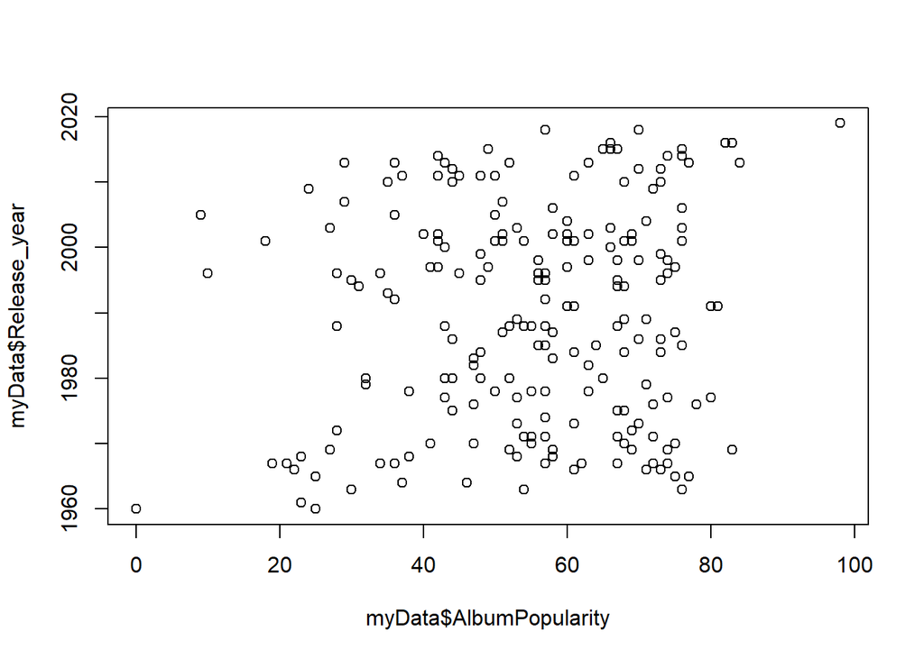

```r
plot(myData$AlbumPopularity, myData$Release_year)
```

```r
NAData <- na.omit(myData)
cor(NAData$AlbumWeeksOnChart, NAData$Release_year)
```

```
## [1] -0.09070816
```

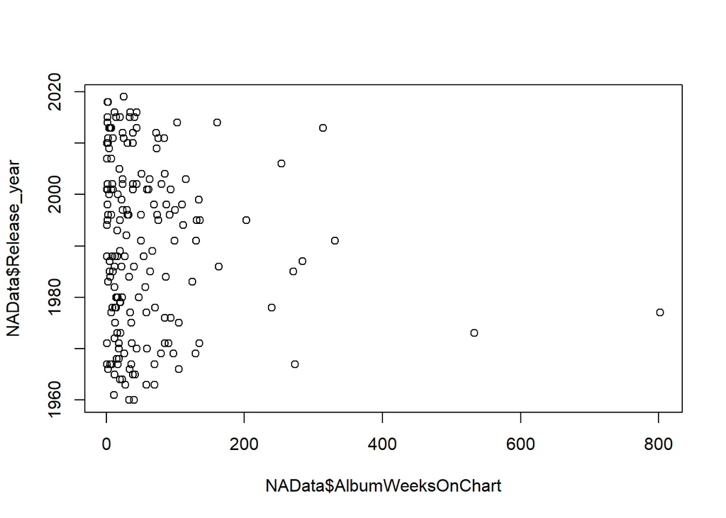

```r
plot(NAData$AlbumWeeksOnChart, NAData$Release_year)
```

```r
NAData <- filter(na.omit(myData), Release_year < 2010)
cor(NAData$AlbumWeeksOnChart, NAData$Release_year)
```

```
## [1] -0.03386394
```

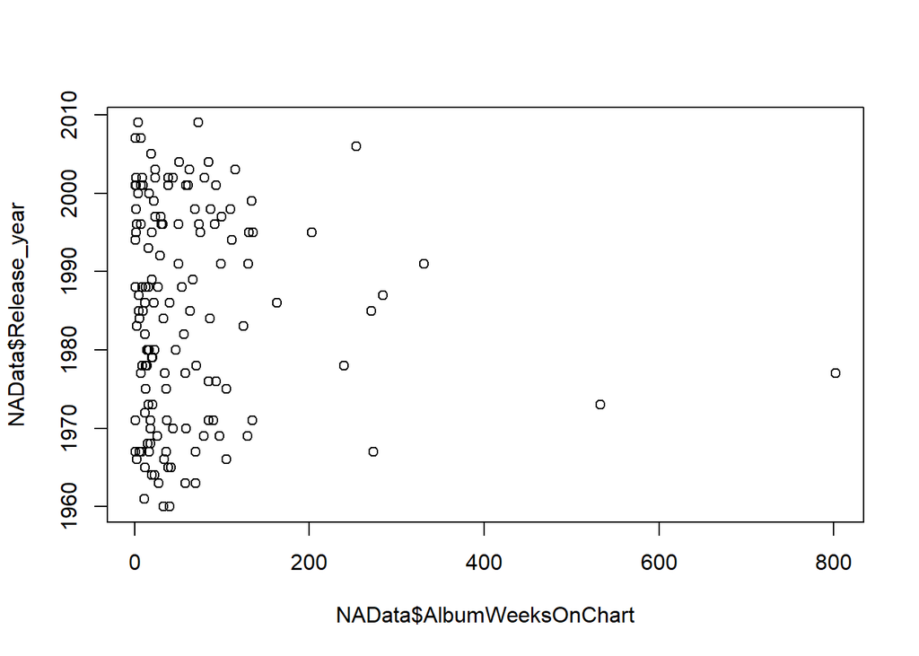

```r
plot(NAData$AlbumWeeksOnChart, NAData$Release_year)
```

```r
musicalData <- select(ungroup(myData), -ArtistNumFollowers, -ArtistPopularity, -Release_year, -Release_month, -Season, -isPop, -isRock, -isIndie, -isFolk, -isMetal, -isTechno, -isBlues, -isRap, -isPunk,-isJazz)
```

```r
library(corrgram)
```

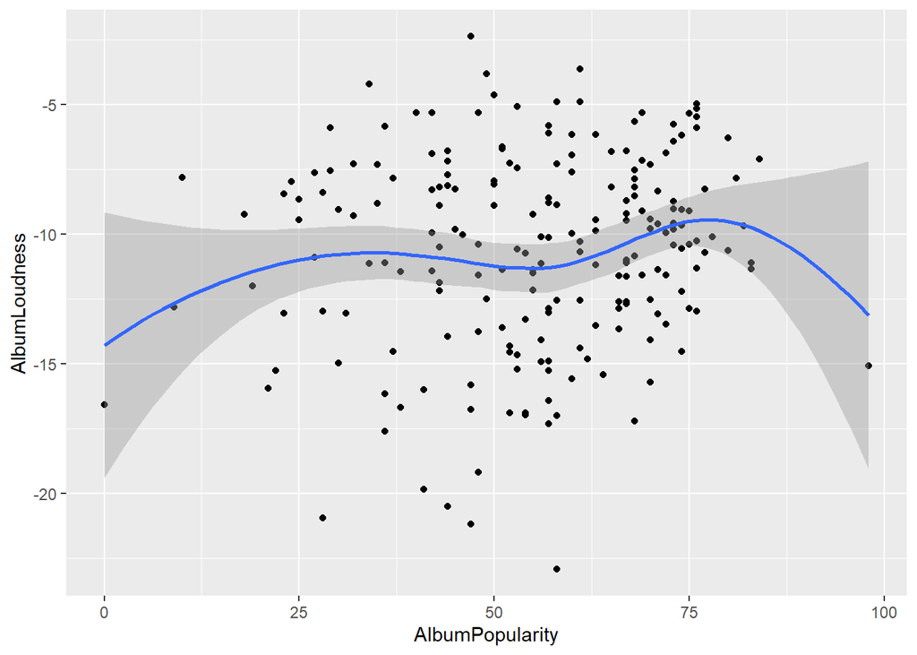

```r
library(corrplot)
correlations <- cor(musicalData)
musicalData2 <- mutate(na.omit(musicalData), AlbumBestChartPosition = 100 -AlbumBestChartPosition)
correlations2 <- cor((musicalData2))
{musicalData %>% ggplot(aes(x = AlbumPopularity, y = AlbumLoudness))} +
    geom_point()  + geom_smooth()
```

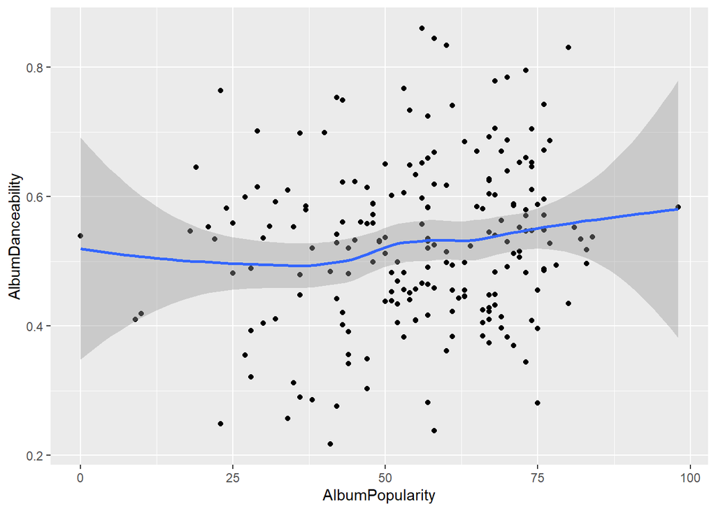

```r
{musicalData %>% ggplot(aes(x = AlbumPopularity, y = AlbumDanceability))} +
    geom_point()  + geom_smooth()
```

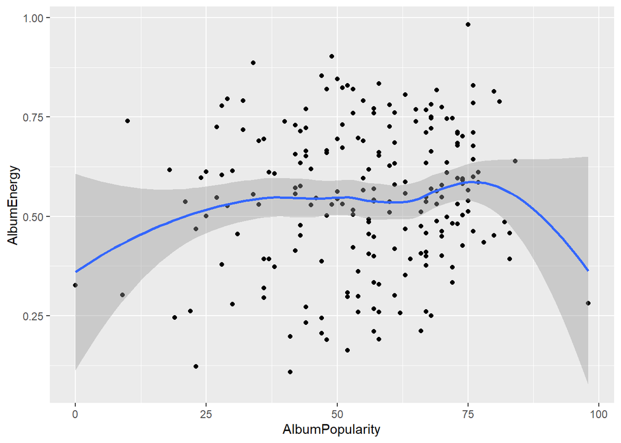

```r
{musicalData %>% ggplot(aes(x = AlbumPopularity, y = AlbumEnergy))} +
    geom_point()  + geom_smooth()
```

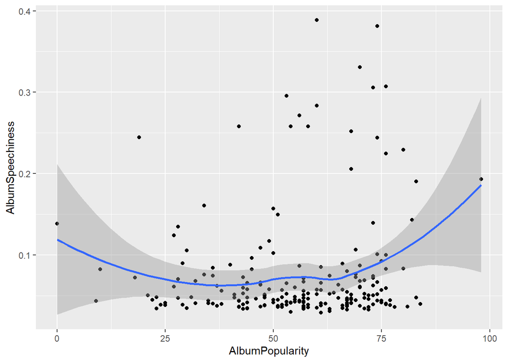

```r
{musicalData %>% ggplot(aes(x = AlbumPopularity, y = AlbumSpeechiness))} +
    geom_point()  + geom_smooth()
```

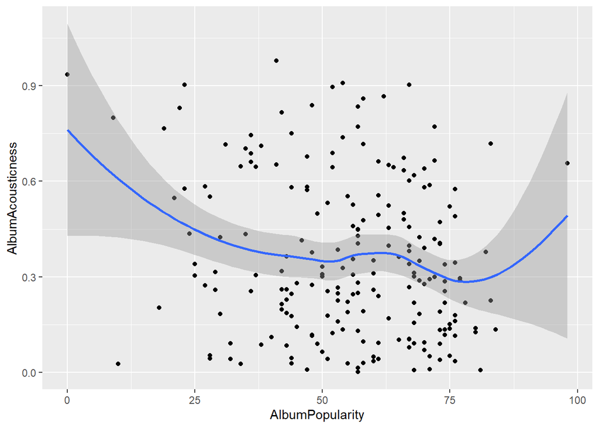

```r
{musicalData %>% ggplot(aes(x = AlbumPopularity, y = AlbumAcousticness))} +
    geom_point()  + geom_smooth()
```

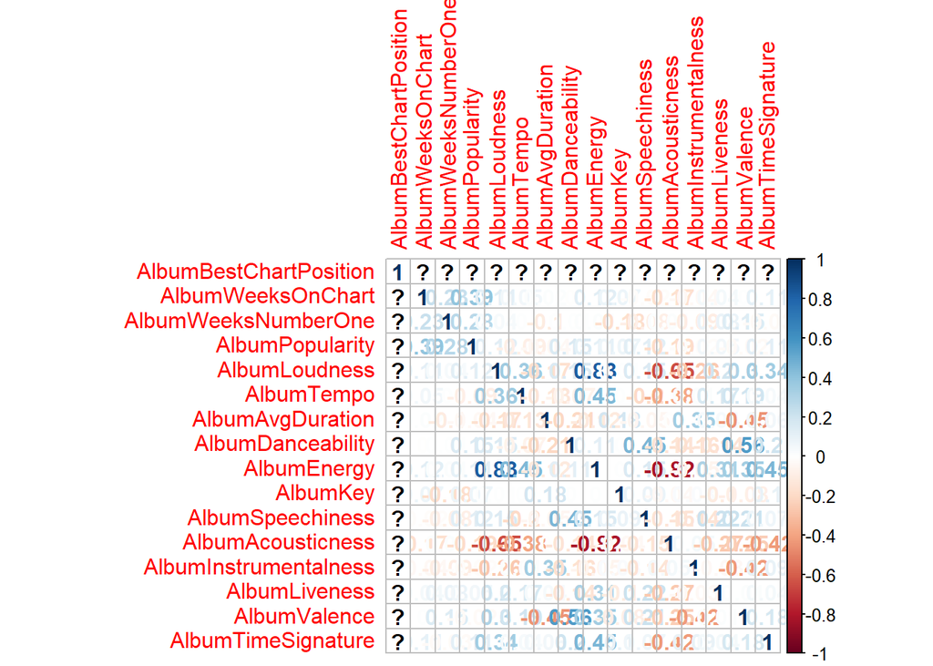

```r
corrplot(correlations, method = "number")
```

```r
analysis <- function(myData)
{
    print(mean(myData$AlbumPopularity))
    corData <- select(ungroup(myData), -ArtistNumFollowers, -ArtistPopularity, -Release_year, -Release_month, -Season, -isPop, -isRock, -isIndie, -isFolk, -isMetal, -isTechno, -isBlues, -isRap, -isPunk,-isJazz)
    correlations <- cor(corData)
    corrplot(correlations, method = "color")
}

rap <- filter(myData, isRap == TRUE)
cor(rap$AlbumPopularity, rap$AlbumAcousticness)
```

```
## [1] 0.3297751
```

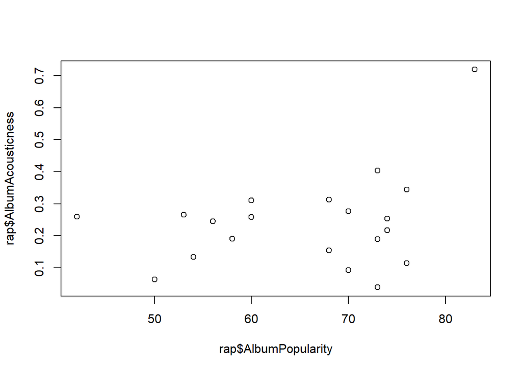

```r
plot(rap$AlbumPopularity, rap$AlbumAcousticness)
```

```r
pop <- filter(myData, isPop == TRUE)
indie <- filter(myData, isIndie == TRUE)
folk <- filter(myData, isFolk == TRUE)
metal <- filter(myData, isMetal == TRUE)
techno <- filter(myData, isTechno == TRUE)
jazz <- filter(myData, isJazz == TRUE)
blues <- filter(myData, isBlues == TRUE)
punk <- filter(myData, isPunk == TRUE)
rock <- filter(myData, isRock == TRUE)

print("rap")
```

```
## [1] "rap"
```

```r
analysis(rap)
```

```
## [1] 65.55
```

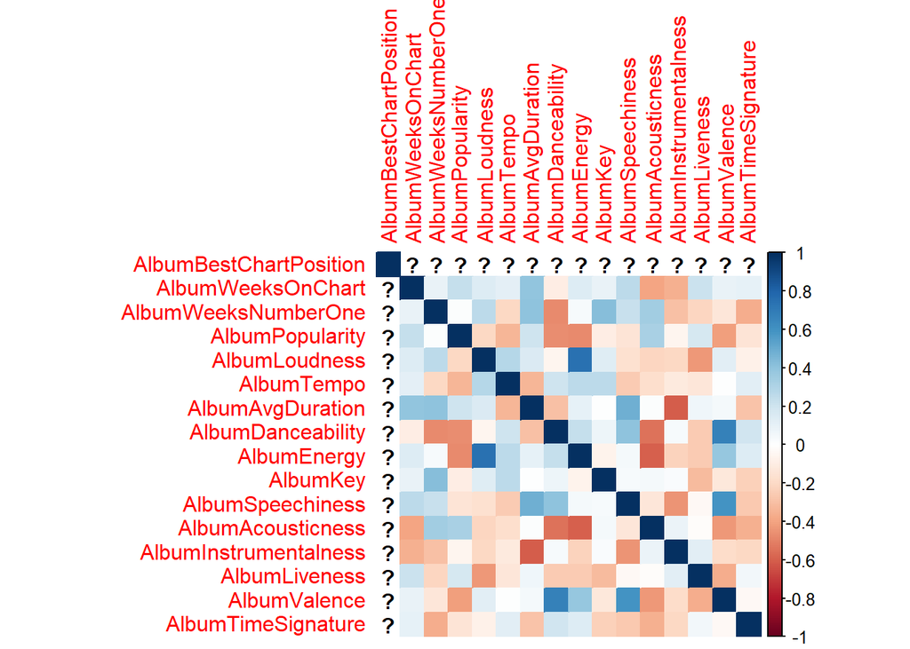

```r
print("rock")
```

```
## [1] "rock"
```

```r
analysis(rock)
```

```
## [1] 55.89552
```

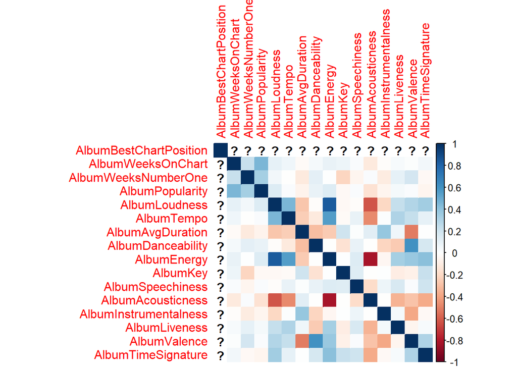

```r
print("Indie")
```

```
## [1] "Indie"
```

```r
analysis(indie)
```

```
## [1] 58.74419
```

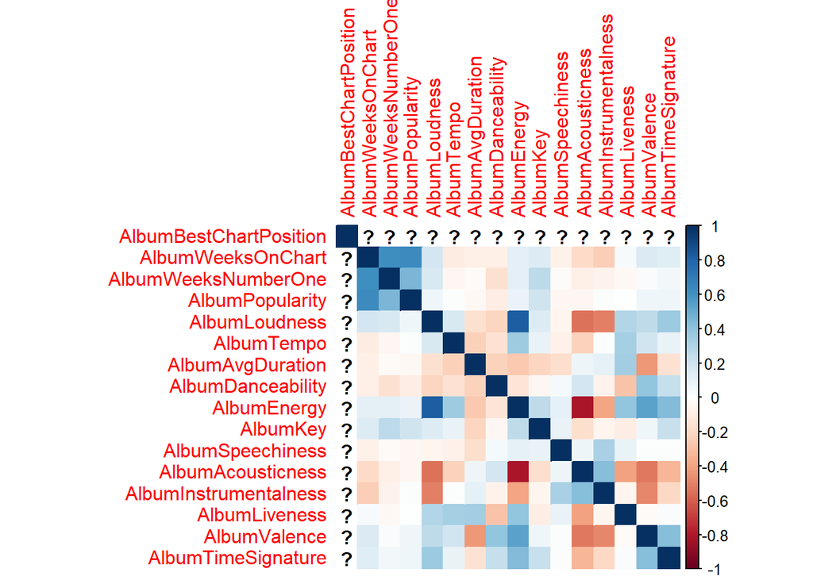

```r
print("techno")
```

```
## [1] "techno"
```

```r
analysis(techno)
```

```
## [1] 56.73077
```

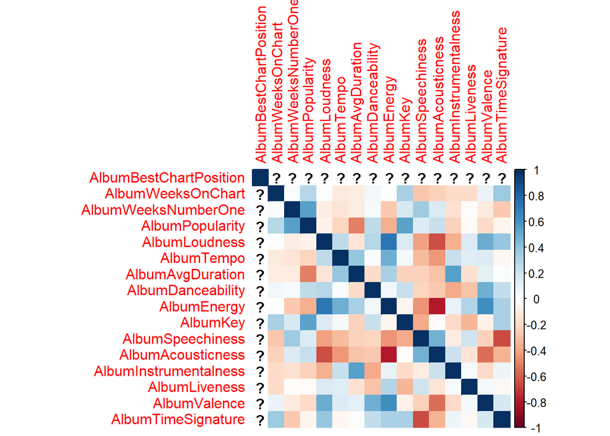

```r
print("pop")
```

```
## [1] "pop"
```

```r
analysis(pop)
```

```
## [1] 53.69159
```

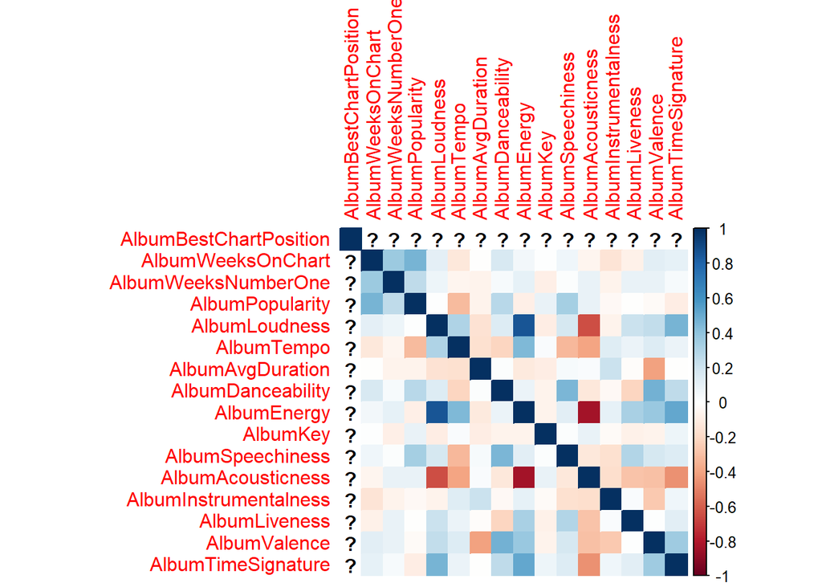

```r
print("folk")
```

```
## [1] "folk"
```

```r
analysis(folk)
```

```
## [1] 50.4
```

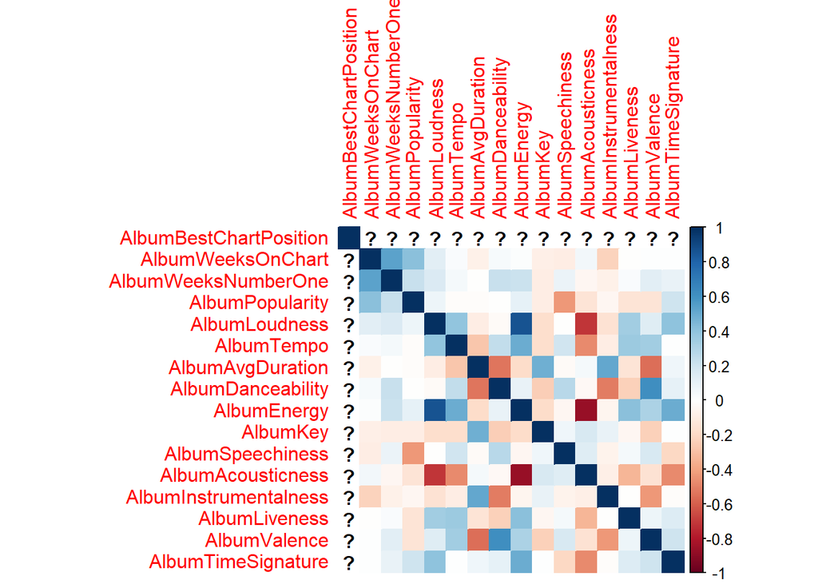

```r
print("jazz")
```

```
## [1] "jazz"
```

```r
analysis(jazz)
```

```
## [1] 41.28571
```

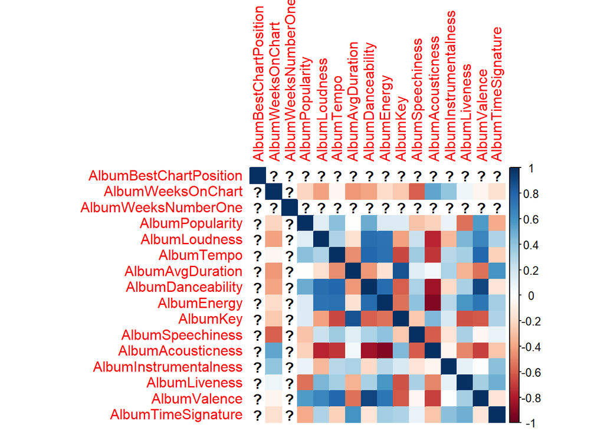

```r
print("blues")
```

```
## [1] "blues"
```

```r
analysis(blues)
```

```
## [1] 60.90476
```

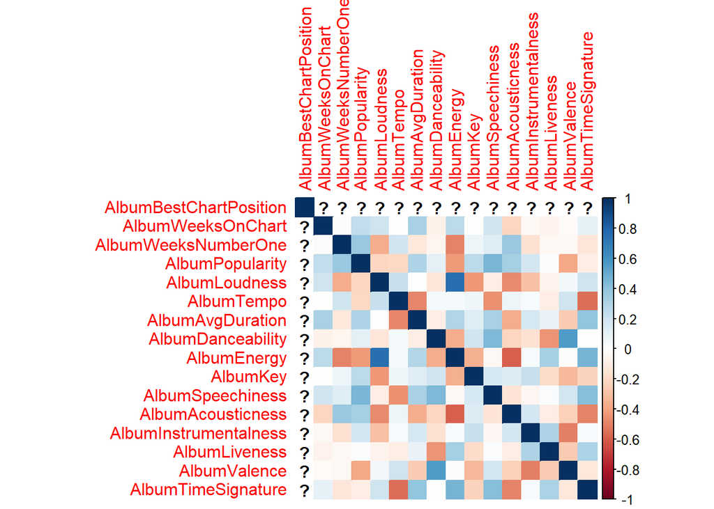

```r
print("punk")
```

```
## [1] "punk"
```

```r
analysis(punk)
```

```
## [1] 48.32
```

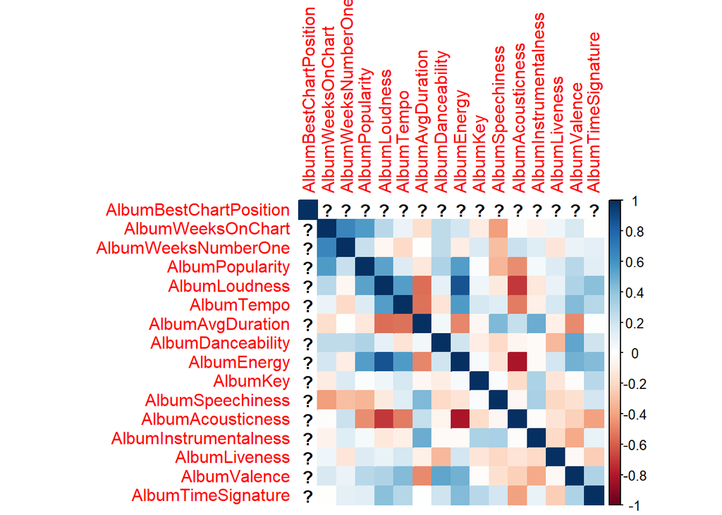

```r
#tempo
model1 <- glm(AlbumPopularity ~ AlbumDanceability + AlbumLoudness + AlbumSpeechiness + AlbumEnergy + AlbumAcousticness,data = myData, family = quasi(link = "log", variance = "mu^2"))
summary(model1)
```

```
##
## Call:
## glm(formula = AlbumPopularity ~ AlbumDanceability + AlbumLoudness +
##     AlbumSpeechiness + AlbumEnergy + AlbumAcousticness, family = quasi(link = "log",
##     variance = "mu^2"), data = myData)
##
## Deviance Residuals:
##      Min        1Q    Median        3Q       Max
## -2.38572  -0.19432   0.01961   0.21677   0.64610
##
## Coefficients:
##                   Estimate Std. Error t value Pr(>|t|)
## (Intercept)        4.33612    0.29257  14.821   <2e-16 ***
## AlbumDanceability  0.24674    0.18991   1.299   0.1953
## AlbumLoudness      0.01018    0.01006   1.012   0.3127
## AlbumSpeechiness   0.16470    0.34738   0.474   0.6359
## AlbumEnergy       -0.41225    0.27626  -1.492   0.1372
## AlbumAcousticness -0.36646    0.14850  -2.468   0.0144 *
## ---
## Signif. codes:  0 '***' 0.001 '**' 0.01 '*' 0.05 '.' 0.1 ' ' 1
##
## (Dispersion parameter for quasi family taken to be 0.09160589)
##
##     Null deviance: 29.749  on 209  degrees of freedom
## Residual deviance: 28.497  on 204  degrees of freedom
## AIC: NA
##
## Number of Fisher Scoring iterations: 5
```

```r
anova(model1, test= "Chi")
```

```
## Analysis of Deviance Table
##
## Model: quasi, link: log
##
## Response: AlbumPopularity
##
## Terms added sequentially (first to last)
##
##
##                   Df Deviance Resid. Df Resid. Dev Pr(>Chi)
## NULL                                209     29.748
## AlbumDanceability  1  0.45238       208     29.296  0.02627 *
## AlbumLoudness      1  0.22390       207     29.072  0.11796
## AlbumSpeechiness   1  0.02921       206     29.043  0.57232
## AlbumEnergy        1  0.00255       205     29.041  0.86752
## AlbumAcousticness  1  0.54326       204     28.497  0.01488 *
## ---
## Signif. codes:  0 '***' 0.001 '**' 0.01 '*' 0.05 '.' 0.1 ' ' 1
```

```r
print("GAPHERE")
```

```
## [1] "GAPHERE"
```

```r
model2 <- lm((AlbumPopularity) ~ AlbumDanceability + AlbumAcousticness,data = myData)
summary(model2)
```

```
##
## Call:
## lm(formula = (AlbumPopularity) ~ AlbumDanceability + AlbumAcousticness,
##     data = myData)
##
## Residuals:
##     Min      1Q  Median      3Q     Max
## -49.023 -10.806   1.519  13.329  45.010
##
## Coefficients:
##                   Estimate Std. Error t value Pr(>|t|)
## (Intercept)         50.546      5.469   9.242   <2e-16 ***
## AlbumDanceability   17.152      9.225   1.859   0.0644 .
## AlbumAcousticness  -11.524      4.649  -2.479   0.0140 *
## ---
## Signif. codes:  0 '***' 0.001 '**' 0.01 '*' 0.05 '.' 0.1 ' ' 1
##
## Residual standard error: 16.48 on 207 degrees of freedom
## Multiple R-squared:  0.05103,    Adjusted R-squared:  0.04186
## F-statistic: 5.566 on 2 and 207 DF,  p-value: 0.004422
```

```r
anova(model2, test= "Chi")
```

```
## Analysis of Variance Table
##
## Response: (AlbumPopularity)
##                    Df Sum Sq Mean Sq F value  Pr(>F)
## AlbumDanceability   1   1354 1353.81  4.9871 0.02661 *
## AlbumAcousticness   1   1668 1667.88  6.1441 0.01398 *
## Residuals         207  56193  271.46
## ---
## Signif. codes:  0 '***' 0.001 '**' 0.01 '*' 0.05 '.' 0.1 ' ' 1
```

```r
library(leaps)
```

```r
musicalData1 <- select(ungroup(myData), -ArtistNumFollowers, -ArtistPopularity, -Release_year, -Release_month, -Season, -isPop, -isRock, -isIndie, -isFolk, -isMetal, -isTechno, -isBlues, -isRap, -isPunk,-isJazz, -AlbumBestChartPosition,  -AlbumWeeksOnChart, -AlbumWeeksNumberOne)
models<-regsubsets(AlbumPopularity~. ,musicalData, nvmax = 8 )
summary(models)
```

```
## Subset selection object
## Call: regsubsets.formula(AlbumPopularity ~ ., musicalData, nvmax = 8)
## 15 Variables  (and intercept)
##                        Forced in Forced out
## AlbumBestChartPosition     FALSE      FALSE
## AlbumWeeksOnChart          FALSE      FALSE
## AlbumWeeksNumberOne        FALSE      FALSE
## AlbumLoudness              FALSE      FALSE
## AlbumTempo                 FALSE      FALSE
## AlbumAvgDuration           FALSE      FALSE
## AlbumDanceability          FALSE      FALSE
## AlbumEnergy                FALSE      FALSE
## AlbumKey                   FALSE      FALSE
## AlbumSpeechiness           FALSE      FALSE
## AlbumAcousticness          FALSE      FALSE
## AlbumInstrumentalness      FALSE      FALSE
## AlbumLiveness              FALSE      FALSE
## AlbumValence               FALSE      FALSE
## AlbumTimeSignature         FALSE      FALSE
## 1 subsets of each size up to 8
## Selection Algorithm: exhaustive
##          AlbumBestChartPosition AlbumWeeksOnChart AlbumWeeksNumberOne
## 1  ( 1 ) " "                    "*"               " "
## 2  ( 1 ) " "                    "*"               "*"
## 3  ( 1 ) " "                    "*"               "*"
## 4  ( 1 ) "*"                    "*"               "*"
## 5  ( 1 ) "*"                    "*"               "*"
## 6  ( 1 ) "*"                    "*"               "*"
## 7  ( 1 ) "*"                    "*"               "*"
## 8  ( 1 ) "*"                    "*"               "*"
##          AlbumLoudness AlbumTempo AlbumAvgDuration AlbumDanceability
## 1  ( 1 ) " "           " "        " "              " "
## 2  ( 1 ) " "           " "        " "              " "
## 3  ( 1 ) " "           " "        " "              " "
## 4  ( 1 ) " "           " "        " "              " "
## 5  ( 1 ) " "           " "        " "              "*"
## 6  ( 1 ) " "           " "        " "              "*"
## 7  ( 1 ) " "           " "        " "              "*"
## 8  ( 1 ) " "           " "        "*"              "*"
##          AlbumEnergy AlbumKey AlbumSpeechiness AlbumAcousticness
```

[output cut: 11 more lines]

```
## 3  ( 1 ) " "                   " "           " "
## 4  ( 1 ) " "                   " "           " "
## 5  ( 1 ) " "                   " "           "*"
## 6  ( 1 ) " "                   " "           "*"
## 7  ( 1 ) " "                   " "           "*"
## 8  ( 1 ) " "                   " "           "*"
##          AlbumTimeSignature
## 1  ( 1 ) " "
## 2  ( 1 ) " "
## 3  ( 1 ) " "
## 4  ( 1 ) " "
## 5  ( 1 ) " "
## 6  ( 1 ) " "
## 7  ( 1 ) " "
## 8  ( 1 ) " "
```

```r
musicalData2 <- select(ungroup(myData), -ArtistNumFollowers, -ArtistPopularity, -AlbumBestChartPosition,  -AlbumWeeksOnChart, -AlbumWeeksNumberOne)
models<-regsubsets(AlbumPopularity~. ,musicalData2, nvmax = 8 )
```

```
## Reordering variables and trying again:
```

```r
summary(models)
```

```
## Subset selection object
## Call: regsubsets.formula(AlbumPopularity ~ ., musicalData2, nvmax = 8)
## 37 Variables  (and intercept)
##                        Forced in Forced out
## Release_year               FALSE      FALSE
## Release_monthAugust        FALSE      FALSE
## Release_monthDecember      FALSE      FALSE
## Release_monthFebruary      FALSE      FALSE
## Release_monthJanuary       FALSE      FALSE
## Release_monthJuly          FALSE      FALSE
## Release_monthJune          FALSE      FALSE
## Release_monthMarch         FALSE      FALSE
## Release_monthMay           FALSE      FALSE
## Release_monthNovember      FALSE      FALSE
## Release_monthOctober       FALSE      FALSE
## Release_monthSeptember     FALSE      FALSE
## isPopTRUE                  FALSE      FALSE
## isFolkTRUE                 FALSE      FALSE
## isRockTRUE                 FALSE      FALSE
## isIndieTRUE                FALSE      FALSE
## isTechnoTRUE               FALSE      FALSE
## isRapTRUE                  FALSE      FALSE
## isJazzTRUE                 FALSE      FALSE
## isMetalTRUE                FALSE      FALSE
## isBluesTRUE                FALSE      FALSE
## isPunkTRUE                 FALSE      FALSE
## AlbumLoudness              FALSE      FALSE
## AlbumTempo                 FALSE      FALSE
## AlbumAvgDuration           FALSE      FALSE
## AlbumDanceability          FALSE      FALSE
## AlbumEnergy                FALSE      FALSE
## AlbumKey                   FALSE      FALSE
## AlbumSpeechiness           FALSE      FALSE
## AlbumAcousticness          FALSE      FALSE
## AlbumInstrumentalness      FALSE      FALSE
## AlbumLiveness              FALSE      FALSE
## AlbumValence               FALSE      FALSE
## AlbumTimeSignature         FALSE      FALSE
## Seasonspring               FALSE      FALSE
## Seasonsummer               FALSE      FALSE
```

[output cut: 88 more lines]

```
## 5  ( 1 ) " "              "*"               " "
## 6  ( 1 ) " "              "*"               " "
## 7  ( 1 ) " "              "*"               " "
## 8  ( 1 ) " "              "*"               " "
## 9  ( 1 ) " "              "*"               " "
##          AlbumLiveness AlbumValence AlbumTimeSignature
## 1  ( 1 ) " "           " "          " "
## 2  ( 1 ) " "           " "          " "
## 3  ( 1 ) " "           " "          " "
## 4  ( 1 ) " "           " "          " "
## 5  ( 1 ) " "           " "          " "
## 6  ( 1 ) " "           " "          " "
## 7  ( 1 ) " "           "*"          " "
## 8  ( 1 ) " "           "*"          " "
## 9  ( 1 ) " "           "*"          " "
```

```r
myData <- import("cleanedData.csv", setclass= "tibble")
myData <- {myData %>%
    group_by(ArtistPopularity, ArtistNumFollowers,
             AlbumBestChartPosition, AlbumWeeksOnChart, AlbumWeeksNumberOne,
             AlbumPopularity, Release_year, Release_month, Season, isPop, isFolk,
             isRock, isIndie, isTechno, isRap, isJazz, isMetal, isBlues, isPunk) %>%
    summarize(AlbumLoudness = mean(TrackLoudness),
              AlbumTempo = mean(TrackTempo),
              AlbumAvgDuration = mean(TrackDuration),
              AlbumDanceability = mean(TrackDanceability),
              AlbumEnergy = mean(TrackEnergy),
              AlbumKey = mean(TrackKey),
              AlbumSpeechiness = mean(TrackSpeechiness),
              AlbumAcousticness = mean(TrackAcousticness),
              AlbumInstrumentalness = mean(TrackInstrumentalness),
              AlbumLiveness = mean(TrackLiveness),
              AlbumValence = mean(TrackValence),
              AlbumTimeSignature = mean(TrackTimeSignature),

              AlbumTempo = mean(TrackTempo)
    )}

musicalData3 <- select(ungroup(myData), -ArtistNumFollowers, -ArtistPopularity, -AlbumBestChartPosition,  -AlbumWeeksOnChart, -AlbumWeeksNumberOne, -Release_month, -Season, -AlbumKey)
models<-regsubsets(AlbumPopularity~. ,musicalData3, nvmax = 10)
summary(models)
```

```
## Subset selection object
## Call: regsubsets.formula(AlbumPopularity ~ ., musicalData3, nvmax = 10)
## 22 Variables  (and intercept)
##                       Forced in Forced out
## Release_year              FALSE      FALSE
## isPopTRUE                 FALSE      FALSE
## isFolkTRUE                FALSE      FALSE
## isRockTRUE                FALSE      FALSE
## isIndieTRUE               FALSE      FALSE
## isTechnoTRUE              FALSE      FALSE
## isRapTRUE                 FALSE      FALSE
## isJazzTRUE                FALSE      FALSE
## isMetalTRUE               FALSE      FALSE
## isBluesTRUE               FALSE      FALSE
## isPunkTRUE                FALSE      FALSE
## AlbumLoudness             FALSE      FALSE
## AlbumTempo                FALSE      FALSE
## AlbumAvgDuration          FALSE      FALSE
## AlbumDanceability         FALSE      FALSE
## AlbumEnergy               FALSE      FALSE
## AlbumSpeechiness          FALSE      FALSE
## AlbumAcousticness         FALSE      FALSE
## AlbumInstrumentalness     FALSE      FALSE
## AlbumLiveness             FALSE      FALSE
## AlbumValence              FALSE      FALSE
## AlbumTimeSignature        FALSE      FALSE
## 1 subsets of each size up to 10
## Selection Algorithm: exhaustive
##           Release_year isPopTRUE isFolkTRUE isRockTRUE isIndieTRUE
## 1  ( 1 )  " "          " "       " "        " "        " "
## 2  ( 1 )  " "          " "       " "        " "        " "
## 3  ( 1 )  " "          " "       " "        " "        " "
## 4  ( 1 )  " "          " "       "*"        "*"        " "
## 5  ( 1 )  " "          "*"       " "        " "        " "
## 6  ( 1 )  " "          "*"       " "        " "        "*"
## 7  ( 1 )  " "          "*"       " "        "*"        " "
## 8  ( 1 )  " "          "*"       " "        "*"        " "
## 9  ( 1 )  " "          "*"       " "        "*"        " "
## 10  ( 1 ) " "          "*"       "*"        "*"        " "
##           isTechnoTRUE isRapTRUE isJazzTRUE isMetalTRUE isBluesTRUE
```

[output cut: 39 more lines]

```
## 7  ( 1 )  " "                   " "           "*"
## 8  ( 1 )  " "                   " "           "*"
## 9  ( 1 )  " "                   " "           "*"
## 10  ( 1 ) " "                   " "           "*"
##           AlbumTimeSignature
## 1  ( 1 )  " "
## 2  ( 1 )  " "
## 3  ( 1 )  " "
## 4  ( 1 )  " "
## 5  ( 1 )  " "
## 6  ( 1 )  " "
## 7  ( 1 )  " "
## 8  ( 1 )  " "
## 9  ( 1 )  " "
## 10  ( 1 ) " "
```

```r
musicalData4 <- select(ungroup(myData), -ArtistNumFollowers, -ArtistPopularity, -AlbumBestChartPosition,  -AlbumWeeksOnChart, -AlbumWeeksNumberOne, -Release_month, -Season, -AlbumKey,-isPop, -isRock, -isIndie, -isFolk, -isMetal, -isTechno, -isBlues, -isRap, -isPunk,-isJazz)
models<-regsubsets(AlbumPopularity~. ,musicalData4, nvmax = 10)
summary(models)
```

```
## Subset selection object
## Call: regsubsets.formula(AlbumPopularity ~ ., musicalData4, nvmax = 10)
## 12 Variables  (and intercept)
##                       Forced in Forced out
## Release_year              FALSE      FALSE
## AlbumLoudness             FALSE      FALSE
## AlbumTempo                FALSE      FALSE
## AlbumAvgDuration          FALSE      FALSE
## AlbumDanceability         FALSE      FALSE
## AlbumEnergy               FALSE      FALSE
## AlbumSpeechiness          FALSE      FALSE
## AlbumAcousticness         FALSE      FALSE
## AlbumInstrumentalness     FALSE      FALSE
## AlbumLiveness             FALSE      FALSE
## AlbumValence              FALSE      FALSE
## AlbumTimeSignature        FALSE      FALSE
## 1 subsets of each size up to 10
## Selection Algorithm: exhaustive
##           Release_year AlbumLoudness AlbumTempo AlbumAvgDuration
## 1  ( 1 )  " "          " "           " "        " "
## 2  ( 1 )  " "          " "           "*"        " "
## 3  ( 1 )  " "          " "           " "        " "
## 4  ( 1 )  " "          " "           "*"        " "
## 5  ( 1 )  " "          " "           "*"        "*"
## 6  ( 1 )  " "          " "           "*"        "*"
## 7  ( 1 )  "*"          "*"           "*"        "*"
## 8  ( 1 )  "*"          "*"           "*"        "*"
## 9  ( 1 )  "*"          "*"           "*"        "*"
## 10  ( 1 ) "*"          "*"           "*"        "*"
##           AlbumDanceability AlbumEnergy AlbumSpeechiness AlbumAcousticness
## 1  ( 1 )  " "               " "         " "              "*"
## 2  ( 1 )  " "               " "         " "              "*"
## 3  ( 1 )  "*"               " "         " "              "*"
## 4  ( 1 )  "*"               " "         " "              "*"
## 5  ( 1 )  "*"               " "         " "              "*"
## 6  ( 1 )  "*"               " "         " "              "*"
## 7  ( 1 )  "*"               " "         " "              "*"
## 8  ( 1 )  "*"               " "         " "              "*"
## 9  ( 1 )  "*"               "*"         " "              "*"
## 10  ( 1 ) "*"               "*"         " "              "*"
##           AlbumInstrumentalness AlbumLiveness AlbumValence
## 1  ( 1 )  " "                   " "           " "
## 2  ( 1 )  " "                   " "           " "
## 3  ( 1 )  " "                   " "           "*"
## 4  ( 1 )  " "                   " "           "*"
## 5  ( 1 )  " "                   " "           "*"
## 6  ( 1 )  " "                   "*"           "*"
## 7  ( 1 )  " "                   " "           "*"
## 8  ( 1 )  " "                   "*"           "*"
## 9  ( 1 )  " "                   "*"           "*"
## 10  ( 1 ) " "                   "*"           "*"
##           AlbumTimeSignature
## 1  ( 1 )  " "
## 2  ( 1 )  " "
## 3  ( 1 )  " "
## 4  ( 1 )  " "
## 5  ( 1 )  " "
## 6  ( 1 )  " "
## 7  ( 1 )  " "
## 8  ( 1 )  " "
## 9  ( 1 )  " "
## 10  ( 1 ) "*"
```

```r
GoodModel  <-  lm((AlbumPopularity) ~ (Release_month == "January") + AlbumAcousticness +AlbumValence + AlbumDanceability + isPunk +isBlues + isJazz+ isRock + isPop,data = myData)
summary(GoodModel)
```

```
##
## Call:
## lm(formula = (AlbumPopularity) ~ (Release_month == "January") +
##     AlbumAcousticness + AlbumValence + AlbumDanceability + isPunk +
##     isBlues + isJazz + isRock + isPop, data = myData)
##
## Residuals:
##     Min      1Q  Median      3Q     Max
## -44.552 -10.478   0.965  11.278  45.016
##
## Coefficients:
##                                Estimate Std. Error t value Pr(>|t|)
## (Intercept)                      52.088      6.756   7.710 5.79e-13 ***
## Release_month == "January"TRUE   -6.727      2.887  -2.330 0.020817 *
## AlbumAcousticness               -15.423      4.438  -3.475 0.000626 ***
## AlbumValence                    -28.119      8.063  -3.487 0.000600 ***
## AlbumDanceability                43.433     12.190   3.563 0.000458 ***
## isPunkTRUE                       -9.610      3.463  -2.775 0.006045 **
## isBluesTRUE                       9.195      3.651   2.519 0.012562 *
## isJazzTRUE                      -12.782      6.093  -2.098 0.037175 *
## isRockTRUE                        7.653      2.694   2.841 0.004961 **
## isPopTRUE                        -6.230      2.147  -2.902 0.004120 **
## ---
## Signif. codes:  0 '***' 0.001 '**' 0.01 '*' 0.05 '.' 0.1 ' ' 1
##
## Residual standard error: 15.27 on 200 degrees of freedom
## Multiple R-squared:  0.2121, Adjusted R-squared:  0.1767
## F-statistic: 5.983 on 9 and 200 DF,  p-value: 2.065e-07
```

```r
anova(GoodModel)
```

```
## Analysis of Variance Table
##
## Response: (AlbumPopularity)
##                             Df Sum Sq Mean Sq F value    Pr(>F)
## Release_month == "January"   1    926  925.90  3.9692 0.0476996 *
## AlbumAcousticness            1   2202 2202.36  9.4412 0.0024172 **
## AlbumValence                 1    391  390.66  1.6747 0.1971241
## AlbumDanceability            1   2726 2725.60 11.6843 0.0007637 ***
## isPunk                       1    904  903.57  3.8735 0.0504366 .
## isBlues                      1    672  671.82  2.8800 0.0912425 .
## isJazz                       1   1230 1229.55  5.2709 0.0227211 *
## isRock                       1   1546 1545.78  6.6265 0.0107699 *
## isPop                        1   1965 1964.85  8.4230 0.0041205 **
## Residuals                  200  46654  233.27
## ---
## Signif. codes:  0 '***' 0.001 '**' 0.01 '*' 0.05 '.' 0.1 ' ' 1
```